# extras2

# 13–2 Errors and Power

In a hypothesis test, the null is assumed until there is strong evidence to suggest we should reject it. Of course, the outcome of a single hypothesis test does not necessarily lead to the correct result—the $p$-value (or whatever rubric you use) only represents a *likelihood*, and there’s always a chance the conclusion we draw from a given test is the *wrong* conclusion, even if the likelihood is very low.

## Type I and Type II Errors

There are two kinds of error we can make in a hypothesis test:

- **Type I Error:** rejecting the null, when the null is *actually* true. The probability of type I error is no more than the significance level of a test.

  Can you see why?
- **Type II Error:** failing to reject the null, when the null *actually* is false.

|  | retain null | reject null |
| --- | --- | --- |
| $H_0$ true | $\checkmark$ | type I error |
| $H_0$ false | type II error | $\checkmark$ |

The foremost goal in hypothesis testing is ensuring the chance of type I error is low. Since the type I error is determined by the significance level, you must choose a significance level that is appropriate for the context—e.g. if type I errors are particularly dangerous, you should use a small significance level (e.g. $\alpha = 0.01$ or $\alpha = 0.005$), to minimize your chance of rejecting the null when it’s actually true.

Since most hypothesis tests are out to *disprove* something, it would be particularly terrible if you rejected a null that was actually true.

The two plots below should help you visualize the type I and type II error. Using the same example as above, the left figure shows the type I error if the true mean wage gap is really 12.36% (i.e. $H_0$ true). The right figure shows the type II error if the true mean wage gap is really 8% (i.e. $H_0$ false), with true distribution overlaid in pink:

[figure not shown]

Note that the type I error is simply the rejection region of the test ($\alpha$). From the figure above you should be able to see why reducing the type I error must also increase the type II error.

Decreasing the chance of type I error increases the chance of type II error, and vice versa—if a judge decided to reduce the number of false convictions by increasing the burden of proof required to demonstrate guilt, this would also inevitably result in more actual criminals getting away with their torts.

## The power of a test

Another useful concept in hypothsis testing is *power*—this is the probability of *correctly* rejecting a false null. Note that power is the complement of type II error, i.e. Power = 1 - T2E. The secondary goal in hypothesis testing, after choosing the test with the smallest type I error, is to choose the test with maximum power—typically we want power to be greater than 0.8 (i.e. the probability of type II error to be smaller than 0.2).

Using the same example as above, the power of the test can be visualized as the following region:

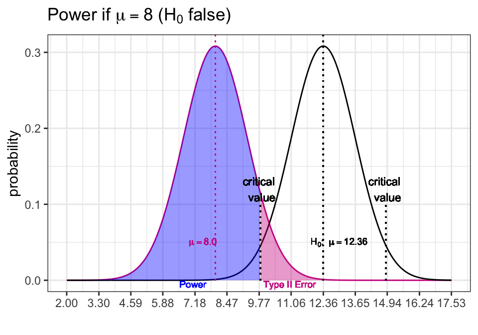

The further away the true mean is from the proposed mean, the higher the power of the test. To see this mathematically, we’ll consider something known as the **power function**, $\beta$, which describes the power of a test as a function of the true parameter $\mu$, i.e. $\beta = \beta(\mu)$. Since power is the probability of correctly rejecting the null, the power function for a two-tailed test is:

Not to be confused with the regression coefficient, which is also denoted $\beta$.

$$\beta(\mu) = {\text{P}}(t > c) + {\text{P}}(t < -c)$$

where $c = t_{\{(1-\alpha/2),df=n-1 \}}$. In full, this can be expressed:

$$\begin{aligned}
\beta(\mu) &= {\text{P}}(t > c) + {\text{P}}(t < -c)\\
&= {\text{P}}\bigg( \frac{(\bar X - \mu_{H_0})}{s/\sqrt n} > c \bigg) + {\text{P}}\bigg( \frac{(\bar X - \mu_{H_0})}{s/\sqrt n} < -c \bigg)\\
&= 1- {\text{P}}\bigg( \frac{(\bar X - \mu_{H_0})}{s/\sqrt n} < c \bigg) + {\text{P}}\bigg( \frac{(\bar X - \mu_{H_0})}{s/\sqrt n} < -c \bigg)\\
&= 1- {\text{P}}\bigg( \frac{(\bar X - \mu_{H_0}) - \mu}{s/\sqrt n} < c - \frac{\mu}{s/\sqrt n} \bigg) + {\text{P}}\bigg( \frac{(\bar X - \mu_{H_0}) - \mu}{s/\sqrt n} < -c - \frac{\mu}{s/\sqrt n} \bigg) \\
&= 1- {\text{P}}\bigg( \frac{\bar X - \mu}{s/\sqrt n} < c - \frac{\mu - \mu_{H_0}}{s/\sqrt n} \bigg) + {\text{P}}\bigg( \frac{\bar X - \mu}{s/\sqrt n} < -c - \frac{\mu - \mu_{H_0}}{s/\sqrt n} \bigg) \\
&= 1- \Phi \bigg( c - \frac{\sqrt n (\mu - \mu_{H_0})}{s} \bigg) + \Phi \bigg( -c - \frac{\sqrt n (\mu - \mu_{H_0})}{s} \bigg)
\end{aligned}$$

where $\Phi$ is the cdf of the normal distribution (or the $t$-distribution), $\mu$ is the true mean, $\mu_{H_0}$ is the mean under the null, and $c$ is the $Z_{(1-\alpha/2)}$ or $t_{\{(1-\alpha/2),df=n-1 \}}$ value. Below is a plot of the power as a function of the true mean, for the above example with $\mu_{H_0} = 12.36}$:

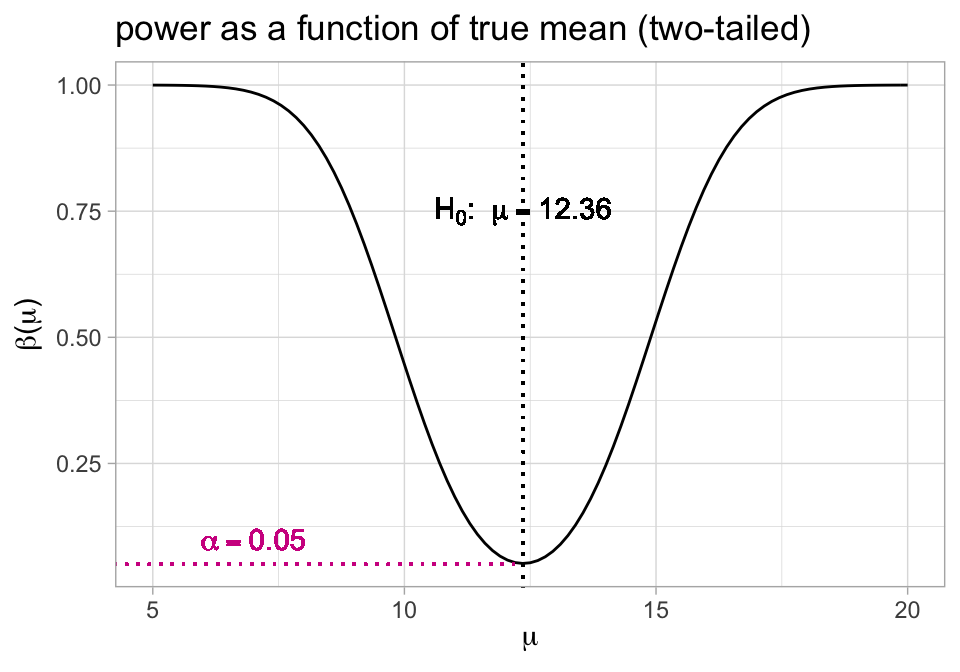

# 13–3 Effect Size and Practical Significance

There is a major issue in hypothesis testing that arises when using large samples. In a two-tailed test the critical values (the bounds of the rejection region) are given by $\mu \pm c \cdot \frac{s}{\sqrt n}$, where $\mu$ is the value of the true mean under the null. Note how the critical values have a dependency on $n$—specifically, that as $n$ becomes larger, the distance between the proposed null and the critical values becomes smaller. This means that for very large $n$, we will reject the null for very small deviations of the observed value from the null—even if the deviations are so small that they have no *practical significance*.

To illustrate this, suppose we are testing the average height in a population, and the null hypothesis is $\mu = 178$ cm. Suppose we have sample data with $\bar X = 179$ cm, $s = 23.5$ cm, and $n = 100$. If we were to conduct the hypothesis test that $\mu \neq 178$ cm at the $\alpha = 0.05$ level, with $c = Z_{(1-\alpha/2)} = 1.96$, we would have a rejection region as follows:

$$\Bigg\{ 178 - 1.96 \cdot \frac{23.5}{\sqrt{100}} \;\; , \;\; 178 + 1.96 \cdot \frac{23.5}{\sqrt{100}} \Bigg\}$$
$$\Longrightarrow \;\;\; \{ 173.39 \; \text{cm},182.61 \; \text{cm} \}$$

i.e. we would reject the null if we observed a value more extreme than the two critical values given. Since our observed value is 179 cm, we do not reject the null, which is an appropriate result since the difference between 178 cm and 179 cm is trivial in the context of people’s heights. But if we do the same test with a sample size $n= 10,000$, the rejection region would be:

$$\Bigg\{ 178 - 1.96 \cdot \frac{23.5}{\sqrt{10000}} \;\; , \;\; 178 + 1.96 \cdot \frac{23.5}{\sqrt{10000}} \Bigg\}$$

$$\Longrightarrow \;\;\; \{ 177.54 \; \text{cm},178.46 \; \text{cm} \}$$

i.e. with $n = 10,000$ we would reject our observed value of 179 cm, even though in reality such a small difference doesn’t really warrant concluding that the true mean height is not 178 cm. This example illustrates the fact that with large samples, results that are not *practically* significant can still be considered *statistically* significant, and the larger the sample size, the more this is going to happen.

One way to control this issue when conducting a study is to *plan* an appropriate sample size—i.e. to *choose* a sample size that will result in practically significant rejections only. First, you must decide what constitutes a practically significant result—e.g. in the above example, suppose we believe that a deviation of at least $\pm 5$ cm from the null mean should permit us to reject the null (i.e. reject if $\bar X < 173$ cm or $\bar X > 183$ cm). What is the sample size necessary to make rejections of this magnitude only, at the $\alpha = 0.05$ level? Simply set the bounds of the rejection equal to the desired values, and solve for $n$, e.g. $\mu + c \cdot \tfrac{s}{\sqrt n} = 183$, which you will find gives $n \approx 85$.

It’s also convenient to introduce a quantity called the **effect size**, $d$, defined as follows:

$$d = \frac{\mu_1 - \mu_2}{s}$$

where $\mu_1 - \mu_2$ is the mean difference (i.e. the desired deviation from the null mean) and $s$ is the standard deviation. E.g.—in the above example the effect size is $d = \frac{5}{23.5} = 0.213$. In general, to determine the appropriate sample size for a study, first determine the smallest effect size that would be considered practically significant, then solve for $n$. It can be shown that $n = \big( \tfrac cd \big)^2$.

Note this definition of effect size is known as *Cohen’s* $d$.